# Homework 3 - Kevin Gong

October 23, 2014

### **A**

The survey I will be examining is the World Values Survey. Specifically, we’ll be looking at the willingness of survey respondents to have homosexual neighbours in Wave 4 (1999-2004) and Wave 6 (2010-2014). The question appears on Card G in both waves and is labeled Question V76 in Wave 4 and V40 in Wave 6. There is a very slight difference in wording between the two waves, though we are not primarily concerned with the difference in wording.

**Wave 4:** “On this list are various groups of people. Could you please sort out any that you would not like to have as neighbors? (CODE AN ANSWER FOR EACH) MENTIONED NOT MENTIONED V68 People with a criminal record 1 2 V69 People of a different race 1 2 V70 Heavy drinkers 1 2 V71 Emotionally unstable people 1 2 V72 Muslims 1 2 V73 Immigrants/foreign workers 1 2 V74 People who have AIDS 2 V75 Drug addicts 1 V76 Homosexuals 1 2 V77 Jews 1 2”

**Wave 6:** “On this list are various groups of people. Could you please mention any that you would not like to have as neighbors? (Code an answer for each group):

Mentioned Not mentioned V36. Drug addicts 1 2 V37. People of a different race 1 2 V38. People who have AIDS 1 2 V39. Immigrants/foreign workers 1 2 V40. Homosexuals 1 2 V41. People of a different religion 1 2 V42. Heavy drinkers 1 2 V43. Unmarried couples living together 1 2 V44. People who speak a different language 1 2"

For these questions, note that a 1 indicates unwillingness to have as a neighbor. Also note that the groups of people listed across the two waves are different as well as being listed in different order.

### **B**

Since the responses are functionally binary (either listed or unlisted as undesirable neighbors), our visualizable statistics will be percentages (out of 100). Thus, we will use a scatterplot to visualize Wave 4 and Wave 6 “Mentioned” percentages grouped by country. This will serve as a way to observe changes in perceptions towards homosexuals across two periods.

### **C**

I’ll be using the basic plot() to create my scatterplot, so I will need the data to look like this:

Country | Wave 4 % Mentioned | Wave 6 % Mentioned

Where the 60,000-70,000+ individual survey respondents are aggregated by country to produce a single proportion. Since the country codes are different across the two waves, we will manually select the countries we will plot and will try to retain only countries that appear in both waves of the survey, though if there are insufficient countries, more may be plotted.

### **D**

We produce the table in the format we specified above. In this step, we need to manually remove countries that existed in both survey waves but were not asked the neighbor question regarding homosexuality.

```r
library(ggplot2)
library(reshape2)
load("~/qmssviz/hw3/WV4.RData")
WV4 = `WV4_Data_rdata_v_2014-04-28`
load("~/qmssviz/hw3/WV6.RData")
WV6 = WV6_Data_spss_v_2014_06_04
#head(WV6)
dim(WV4)
```

```
## [1] 60045   373
```

```r
dim(WV6)
```

```
## [1] 74042   381
```

```r
country_wv4 = unique(WV4$v2)
country_wv6 = unique(WV6$V2)
country_wv4
```

```
##  [1]   8  12  32  50  70 124 152 156 818 356 360 364 368 376 392 400 417
## [18] 807 484 498 912 504 566 586 604 608 630 682 911 702 710 410 724 752
## [35] 834 792 800 840 862 704 716
```

```r
country_wv6
```

```
##  [1]  12  51  36  31 112 170 196 152 156 218 818 233 276 288 368 392 400
## [18] 398 414 417 422 434 458 484 504 528 554 566 586 275 604 608 616 634
## [35] 642 643 646 702 705 410 724 752 158 780 788 792 804 840 858 860 887
## [52] 716
```

```r
country_wv4==country_wv6
```

```
##  [1] FALSE FALSE FALSE FALSE FALSE FALSE FALSE FALSE FALSE FALSE FALSE
## [12] FALSE FALSE FALSE FALSE FALSE FALSE FALSE FALSE FALSE FALSE FALSE
## [23] FALSE FALSE FALSE FALSE FALSE FALSE FALSE FALSE FALSE FALSE FALSE
## [34] FALSE FALSE FALSE FALSE FALSE FALSE FALSE FALSE FALSE FALSE FALSE
## [45] FALSE FALSE FALSE FALSE FALSE FALSE FALSE FALSE
```

```r
country_list = vector()

for(i in 1:length(country_wv4)) {

  if (is.element(country_wv4[i], country_wv6)) {
    country_list[i] = country_wv4[i]
  }

}

country_list2 = country_list[!is.na(country_list)]
country_list2
```

```
##  [1]  12 152 156 818 368 392 400 417 484 504 566 586 604 608 702 410 724
## [18] 752 792 840 716
```

```r
length(country_list2)
```

```
## [1] 21
```

```r
country_matrix = matrix(nrow=21, ncol=3)
country_matrix[,1]=country_list2
country_matrix
```

```
##       [,1] [,2] [,3]
##  [1,]   12   NA   NA
##  [2,]  152   NA   NA
##  [3,]  156   NA   NA
##  [4,]  818   NA   NA
##  [5,]  368   NA   NA
##  [6,]  392   NA   NA
##  [7,]  400   NA   NA
##  [8,]  417   NA   NA
##  [9,]  484   NA   NA
## [10,]  504   NA   NA
## [11,]  566   NA   NA
## [12,]  586   NA   NA
## [13,]  604   NA   NA
## [14,]  608   NA   NA
## [15,]  702   NA   NA
## [16,]  410   NA   NA
## [17,]  724   NA   NA
## [18,]  752   NA   NA
## [19,]  792   NA   NA
## [20,]  840   NA   NA
## [21,]  716   NA   NA
```

```r
sum(WV4$v2==country_wv4[2])
```

```
## [1] 1282
```

```r
sum(WV4$v76[WV4$v2==country_wv4[2]]==2)
```

```
## [1] 247
```

```r
sum(WV6$V40[WV6$V2==country_wv6[1]]==2)
```

```
## [1] 503
```

```r
for(i in 1:length(country_list2)){
  mention_wv4 = sum(WV4$v76[WV4$v2==country_list2[i]]==1)
  total_wv4 = sum(WV4$v2==country_list2[i])
  proportion_wv4 = mention_wv4/total_wv4
  country_matrix[i,2] = proportion_wv4

  mention_wv6 = sum(WV6$V40[WV6$V2==country_list2[i]]==1)
  total_wv6 = sum(WV6$V2==country_list2[i])
  proportion_wv6 = mention_wv6/total_wv6
  country_matrix[i,3] = proportion_wv6

}
country_matrix
```

```
##       [,1]   [,2]    [,3]
##  [1,]   12 0.8073 0.58083
##  [2,]  152 0.3350 0.25700
##  [3,]  156 0.7320 0.51652
##  [4,]  818 0.9960 0.00000
##  [5,]  368 0.0000 0.80333
##  [6,]  392 0.0000 0.00000
##  [7,]  400 0.9836 0.62000
##  [8,]  417 0.6596 0.77000
##  [9,]  484 0.4254 0.23250
## [10,]  504 0.9089 0.85500
## [11,]  566 0.7359 0.70722
## [12,]  586 0.0000 0.57750
## [13,]  604 0.4917 0.44050
## [14,]  608 0.2400 0.27250
## [15,]  702 0.4934 0.30832
## [16,]  410 0.8242 0.77583
## [17,]  724 0.1497 0.05046
## [18,]  752 0.0601 0.03648
## [19,]  792 0.8839 0.83489
## [20,]  840 0.2292 0.20654
## [21,]  716 0.6776 0.89067
```

```r
country_matrix2 = country_matrix[-c(4:6),]
country_matrix2
```

```
##       [,1]   [,2]    [,3]
##  [1,]   12 0.8073 0.58083
##  [2,]  152 0.3350 0.25700
##  [3,]  156 0.7320 0.51652
##  [4,]  400 0.9836 0.62000
##  [5,]  417 0.6596 0.77000
##  [6,]  484 0.4254 0.23250
##  [7,]  504 0.9089 0.85500
##  [8,]  566 0.7359 0.70722
##  [9,]  586 0.0000 0.57750
## [10,]  604 0.4917 0.44050
## [11,]  608 0.2400 0.27250
## [12,]  702 0.4934 0.30832
## [13,]  410 0.8242 0.77583
## [14,]  724 0.1497 0.05046
## [15,]  752 0.0601 0.03648
## [16,]  792 0.8839 0.83489
## [17,]  840 0.2292 0.20654
## [18,]  716 0.6776 0.89067
```

```r
colnames(country_matrix2)[1:3] = c("Country","WV4_percent","WV6_percent")
country_matrix2
```

```
##       Country WV4_percent WV6_percent
##  [1,]      12      0.8073     0.58083
##  [2,]     152      0.3350     0.25700
##  [3,]     156      0.7320     0.51652
##  [4,]     400      0.9836     0.62000
##  [5,]     417      0.6596     0.77000
##  [6,]     484      0.4254     0.23250
##  [7,]     504      0.9089     0.85500
##  [8,]     566      0.7359     0.70722
##  [9,]     586      0.0000     0.57750
## [10,]     604      0.4917     0.44050
## [11,]     608      0.2400     0.27250
## [12,]     702      0.4934     0.30832
## [13,]     410      0.8242     0.77583
## [14,]     724      0.1497     0.05046
## [15,]     752      0.0601     0.03648
## [16,]     792      0.8839     0.83489
## [17,]     840      0.2292     0.20654
## [18,]     716      0.6776     0.89067
```

```r
country_matrix3 = country_matrix2

newnames=c("Algeria","Chile","China","Jordan","Kyrgyzstan","Mexico","Morocco","Nigeria","Pakistan","Peru","Philippines","Singapore","South Korea","Spain","Sweden","Turkey","United States","Zimbabwe")
newnames
```

```
##  [1] "Algeria"       "Chile"         "China"         "Jordan"
##  [5] "Kyrgyzstan"    "Mexico"        "Morocco"       "Nigeria"
##  [9] "Pakistan"      "Peru"          "Philippines"   "Singapore"
## [13] "South Korea"   "Spain"         "Sweden"        "Turkey"
## [17] "United States" "Zimbabwe"
```

```r
newnames2 = as.factor(newnames)
newnames2
```

```
##  [1] Algeria       Chile         China         Jordan        Kyrgyzstan
##  [6] Mexico        Morocco       Nigeria       Pakistan      Peru
## [11] Philippines   Singapore     South Korea   Spain         Sweden
## [16] Turkey        United States Zimbabwe
## 18 Levels: Algeria Chile China Jordan Kyrgyzstan Mexico ... Zimbabwe
```

```r
country_matrix3[,1]=newnames
country_matrix3[,1]
```

```
##  [1] "Algeria"       "Chile"         "China"         "Jordan"
##  [5] "Kyrgyzstan"    "Mexico"        "Morocco"       "Nigeria"
##  [9] "Pakistan"      "Peru"          "Philippines"   "Singapore"
## [13] "South Korea"   "Spain"         "Sweden"        "Turkey"
## [17] "United States" "Zimbabwe"
```

```r
country_matrix3[,1]=as.factor(country_matrix3[,1])
country_matrix3
```

```
##       Country WV4_percent          WV6_percent
##  [1,] "1"     "0.807332293291732"  "0.580833333333333"
##  [2,] "2"     "0.335"              "0.257"
##  [3,] "3"     "0.732"              "0.516521739130435"
##  [4,] "4"     "0.983646770237122"  "0.62"
##  [5,] "5"     "0.659635666347076"  "0.77"
##  [6,] "6"     "0.425407166123778"  "0.2325"
##  [7,] "7"     "0.908872901678657"  "0.855"
##  [8,] "8"     "0.735905044510386"  "0.707220011370097"
##  [9,] "9"     "0"                  "0.5775"
## [10,] "10"    "0.491672218520986"  "0.440495867768595"
## [11,] "11"    "0.24"               "0.2725"
## [12,] "12"    "0.493386243386243"  "0.308316430020284"
## [13,] "13"    "0.824166666666667"  "0.775833333333333"
## [14,] "14"    "0.149710504549214"  "0.0504625735912532"
## [15,] "15"    "0.0600985221674877" "0.0364842454394693"
## [16,] "16"    "0.883857688915025"  "0.834890965732087"
## [17,] "17"    "0.229166666666667"  "0.206541218637993"
## [18,] "18"    "0.677644710578842"  "0.890666666666667"
```

```r
newnames3 = as.matrix(newnames2)

country_matrix4 = cbind(newnames3,as.numeric(country_matrix3[,2]),country_matrix3[,3])
country_matrix4[,2] = as.numeric(country_matrix4[,2])
country_matrix4[,3] = as.numeric(country_matrix4[,3])
colnames(country_matrix4)[1:3] = c("Country","Wave 4 % Mention","Wave 6 % Mention")
country_matrix4
```

```
##       Country         Wave 4 % Mention     Wave 6 % Mention
##  [1,] "Algeria"       "0.807332293291732"  "0.580833333333333"
##  [2,] "Chile"         "0.335"              "0.257"
##  [3,] "China"         "0.732"              "0.516521739130435"
##  [4,] "Jordan"        "0.983646770237122"  "0.62"
##  [5,] "Kyrgyzstan"    "0.659635666347076"  "0.77"
##  [6,] "Mexico"        "0.425407166123778"  "0.2325"
##  [7,] "Morocco"       "0.908872901678657"  "0.855"
##  [8,] "Nigeria"       "0.735905044510386"  "0.707220011370097"
##  [9,] "Pakistan"      "0"                  "0.5775"
## [10,] "Peru"          "0.491672218520986"  "0.440495867768595"
## [11,] "Philippines"   "0.24"               "0.2725"
## [12,] "Singapore"     "0.493386243386243"  "0.308316430020284"
## [13,] "South Korea"   "0.824166666666667"  "0.775833333333333"
## [14,] "Spain"         "0.149710504549214"  "0.0504625735912532"
## [15,] "Sweden"        "0.0600985221674877" "0.0364842454394693"
## [16,] "Turkey"        "0.883857688915025"  "0.834890965732087"
## [17,] "United States" "0.229166666666667"  "0.206541218637993"
## [18,] "Zimbabwe"      "0.677644710578842"  "0.890666666666667"
```

```r
country_matrix4[,2] = country_matrix3[,2]
country_matrix4
```

```
##       Country         Wave 4 % Mention     Wave 6 % Mention
##  [1,] "Algeria"       "0.807332293291732"  "0.580833333333333"
##  [2,] "Chile"         "0.335"              "0.257"
##  [3,] "China"         "0.732"              "0.516521739130435"
##  [4,] "Jordan"        "0.983646770237122"  "0.62"
##  [5,] "Kyrgyzstan"    "0.659635666347076"  "0.77"
##  [6,] "Mexico"        "0.425407166123778"  "0.2325"
##  [7,] "Morocco"       "0.908872901678657"  "0.855"
##  [8,] "Nigeria"       "0.735905044510386"  "0.707220011370097"
##  [9,] "Pakistan"      "0"                  "0.5775"
## [10,] "Peru"          "0.491672218520986"  "0.440495867768595"
## [11,] "Philippines"   "0.24"               "0.2725"
## [12,] "Singapore"     "0.493386243386243"  "0.308316430020284"
## [13,] "South Korea"   "0.824166666666667"  "0.775833333333333"
## [14,] "Spain"         "0.149710504549214"  "0.0504625735912532"
## [15,] "Sweden"        "0.0600985221674877" "0.0364842454394693"
## [16,] "Turkey"        "0.883857688915025"  "0.834890965732087"
## [17,] "United States" "0.229166666666667"  "0.206541218637993"
## [18,] "Zimbabwe"      "0.677644710578842"  "0.890666666666667"
```

```r
#use country_matrix3 for now
```

country_matrix3

### **E**

Now we graph it!

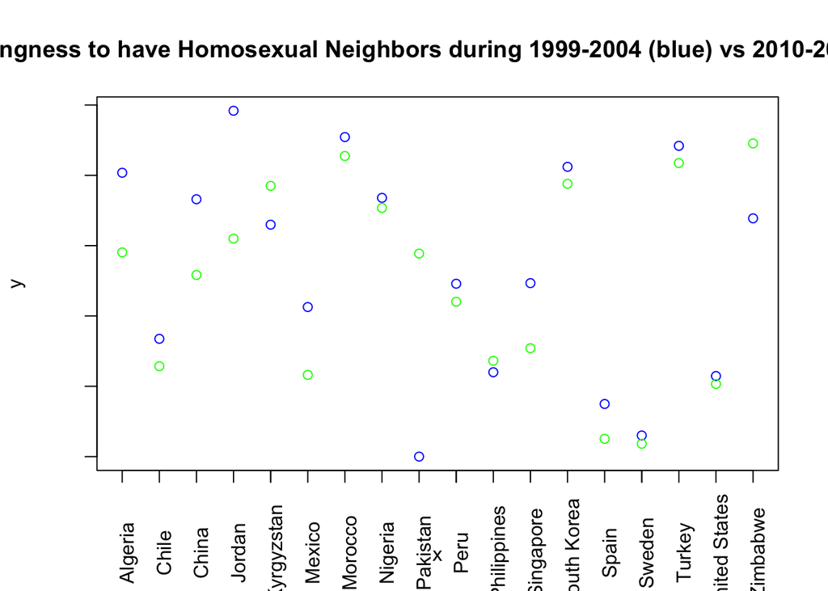

```r
#country_matrix6 = read.table(country_matrix3)

#cm = structure( c(country_matrix3[,1], country_matrix3[,2], country_matrix3[,3]) ,.Dim=c(18,3))
#cm2 = melt(country_matrix3,id.vars=c("Country","Wave4","Wave6"))
#cm2


#country_matrix3
#plot(country_matrix3)

a=as.factor(country_matrix4[,1])


plot(a,country_matrix3[,2],type="p",col="blue",labels=FALSE,main="Unwillingness to have Homosexual Neighbors during 1999-2004 (blue) vs 2010-2014 (green)")
points(a,country_matrix3[,3],col="green")
axis(1, at=seq(1, 18, by=1), labels = FALSE)
text(seq(1, 18, by=1), par("usr")[3] - 0.2, labels = newnames, srt = 90, pos = 1, xpd = TRUE)
```

For most countries, we see that unwillingness to have homosexual neighbors decreases from Wave 4 (blue dot) to Wave 6 (green dot), which makes sense due to the general decrease of homophobia in the past decade. However, note that some countries, such as Kyrgyzstan and Zimbabwe, actually experienced notable increases in unwillingness to have homosexual neighbors.

### **F**

See loops, if statements, etc used in code blocks above.